# NOAA Storm Impacts Analysis

Javier Quintero Ramírez

30/12/2020

```r
knitr::opts_chunk$set(echo = TRUE)
library(dplyr)
```

## Analysis of the impact of storms on public health and the economy in the United States from 1950 to 2011

## ¬ Synopsis

#### The basic objective of this analysis is to explore the National Oceanic and Atmospheric Administration (NOAA) storm database and answer two basic questions about severe weather events:

##### 1. Across the United States, what types of weather events are most damaging to the health of the population?

##### 2. Across the United States, what types of weather events have the greatest economic consequences?

#### NOAA’s database can be downloaded from [here](https://d396qusza40orc.cloudfront.net/repdata%2Fdata%2FStormData.csv.bz2). It contains information about the severe weather events that occurred between 1950 and 2011 and their relationship to public health and economy of the United States in that time period.

#### For further information, here you can see the National Weather Service Storm Data [Documentation](https://d396qusza40orc.cloudfront.net/repdata%2Fpeer2_doc%2Fpd01016005curr.pdf) and the National Climatic Data Center Storm Events [FAQ](https://d396qusza40orc.cloudfront.net/repdata%2Fpeer2_doc%2FNCDC%20Storm%20Events-FAQ%20Page.pdf).

## ¬ Data Processing

#### First, the NOOA’s database is downloaded and read it:

```r
if (!file.exists('./resources/repdata-data-StormData.csv.bz2'))
{
   download.file("http://d396qusza40orc.cloudfront.net/repdata%2Fdata%2FStormData.csv.bz2",
                  destfile = "./resources/repdata-data-StormData.csv.bz2")
}

stormDataBase <- read.csv("./resources/repdata-data-StormData.csv")
```

### Summary

#### Here we can see a summary and the structure of the data:

```r
str(stormDataBase)
```

```
## 'data.frame':    902297 obs. of  37 variables:
##  $ STATE__   : num  1 1 1 1 1 1 1 1 1 1 ...
##  $ BGN_DATE  : chr  "4/18/1950 0:00:00" "4/18/1950 0:00:00" "2/20/1951 0:00:00" "6/8/1951 0:00:00" ...
##  $ BGN_TIME  : chr  "0130" "0145" "1600" "0900" ...
##  $ TIME_ZONE : chr  "CST" "CST" "CST" "CST" ...
##  $ COUNTY    : num  97 3 57 89 43 77 9 123 125 57 ...
##  $ COUNTYNAME: chr  "MOBILE" "BALDWIN" "FAYETTE" "MADISON" ...
##  $ STATE     : chr  "AL" "AL" "AL" "AL" ...
##  $ EVTYPE    : chr  "TORNADO" "TORNADO" "TORNADO" "TORNADO" ...
##  $ BGN_RANGE : num  0 0 0 0 0 0 0 0 0 0 ...
##  $ BGN_AZI   : chr  "" "" "" "" ...
##  $ BGN_LOCATI: chr  "" "" "" "" ...
##  $ END_DATE  : chr  "" "" "" "" ...
##  $ END_TIME  : chr  "" "" "" "" ...
##  $ COUNTY_END: num  0 0 0 0 0 0 0 0 0 0 ...
```

[output cut: 23 more lines]

```r
summary(stormDataBase)
```

```
##     STATE__       BGN_DATE           BGN_TIME          TIME_ZONE
##  Min.   : 1.0   Length:902297      Length:902297      Length:902297
##  1st Qu.:19.0   Class :character   Class :character   Class :character
##  Median :30.0   Mode  :character   Mode  :character   Mode  :character
##  Mean   :31.2
##  3rd Qu.:45.0
##  Max.   :95.0
##
##      COUNTY       COUNTYNAME           STATE              EVTYPE
##  Min.   :  0.0   Length:902297      Length:902297      Length:902297
##  1st Qu.: 31.0   Class :character   Class :character   Class :character
##  Median : 75.0   Mode  :character   Mode  :character   Mode  :character
##  Mean   :100.6
##  3rd Qu.:131.0
##  Max.   :873.0
##
##    BGN_RANGE          BGN_AZI           BGN_LOCATI          END_DATE
##  Min.   :   0.000   Length:902297      Length:902297      Length:902297
##  1st Qu.:   0.000   Class :character   Class :character   Class :character
##  Median :   0.000   Mode  :character   Mode  :character   Mode  :character
##  Mean   :   1.484
##  3rd Qu.:   1.000
##  Max.   :3749.000
##
##    END_TIME           COUNTY_END COUNTYENDN       END_RANGE
##  Length:902297      Min.   :0    Mode:logical   Min.   :  0.0000
##  Class :character   1st Qu.:0    NA's:902297    1st Qu.:  0.0000
##  Mode  :character   Median :0                   Median :  0.0000
##                     Mean   :0                   Mean   :  0.9862
##                     3rd Qu.:0                   3rd Qu.:  0.0000
##                     Max.   :0                   Max.   :925.0000
##
##    END_AZI           END_LOCATI            LENGTH              WIDTH
##  Length:902297      Length:902297      Min.   :   0.0000   Min.   :   0.000
##  Class :character   Class :character   1st Qu.:   0.0000   1st Qu.:   0.000
##  Mode  :character   Mode  :character   Median :   0.0000   Median :   0.000
##                                        Mean   :   0.2301   Mean   :   7.503
##                                        3rd Qu.:   0.0000   3rd Qu.:   0.000
##                                        Max.   :2315.0000   Max.   :4400.000
##
```

[output cut: 25 more lines]

```
##  Min.   :-14451   Min.   :   0   Min.   :-14455   Length:902297
##  1st Qu.:  7247   1st Qu.:   0   1st Qu.:     0   Class :character
##  Median :  8707   Median :   0   Median :     0   Mode  :character
##  Mean   :  6940   Mean   :1452   Mean   :  3509
##  3rd Qu.:  9605   3rd Qu.:3549   3rd Qu.:  8735
##  Max.   : 17124   Max.   :9706   Max.   :106220
##                   NA's   :40
##      REFNUM
##  Min.   :     1
##  1st Qu.:225575
##  Median :451149
##  Mean   :451149
##  3rd Qu.:676723
##  Max.   :902297
##
```

#### Here are described the relevant variables for this analysis:

Health-related variables:

```
FATALITIES: Number of deaths.
INJURIES:   Number of injuries.
```

Economic-related variables:

```
PROPDMG:    Property damaged.
PROPDMGEXP: The units for property damage value.
CROPDMG:    Crop damaged.
CROPDMGEXP: The units for crop damage value.
```

And these is the number of weather events types found in the NOOA’s database:

```r
evtypeList <- unique(toupper(stormDataBase$EVTYPE))
length(evtypeList)
```

```
## [1] 898
```

#### Now we are going to select only the relevants variables:

```r
selectedVariables <- select(stormDataBase,FATALITIES,INJURIES,PROPDMG,PROPDMGEXP,CROPDMG,CROPDMGEXP,EVTYPE)
head(selectedVariables)
```

```
##   FATALITIES INJURIES PROPDMG PROPDMGEXP CROPDMG CROPDMGEXP  EVTYPE
## 1          0       15    25.0          K       0            TORNADO
## 2          0        0     2.5          K       0            TORNADO
## 3          0        2    25.0          K       0            TORNADO
## 4          0        2     2.5          K       0            TORNADO
## 5          0        2     2.5          K       0            TORNADO
## 6          0        6     2.5          K       0            TORNADO
```

#### As there are many types of climatic events, we will try to unify some of them, which have a certain relationship:

```r
selectedVariables$EVTYPE <- gsub('.*SUMMARY*', 'SUMMARY',toupper(selectedVariables$EVTYPE))

selectedVariables$EVTYPE <- gsub('.*DRY.*', 'DROUGHT', toupper(selectedVariables$EVTYPE))
selectedVariables$EVTYPE <- gsub('.*DROUGHT.*', 'DROUGHT', toupper(selectedVariables$EVTYPE))
selectedVariables$EVTYPE <- gsub('.*DRIE.*', 'DROUGHT', toupper(selectedVariables$EVTYPE))

selectedVariables$EVTYPE <- gsub('.*COLD.*', 'FROST', toupper(selectedVariables$EVTYPE))
selectedVariables$EVTYPE <- gsub('.*LOW.*TEMPER.*', 'FROST', toupper(selectedVariables$EVTYPE))
selectedVariables$EVTYPE <- gsub('.*FROST.*', 'FROST', toupper(selectedVariables$EVTYPE))
selectedVariables$EVTYPE <- gsub('.*FREEZ.*', 'FROST', toupper(selectedVariables$EVTYPE))
selectedVariables$EVTYPE <- gsub('.*HAIL.*', 'FROST', toupper(selectedVariables$EVTYPE))

selectedVariables$EVTYPE <- gsub('.*HIGH.*TEMPER.*', 'HEAT WAVES', toupper(selectedVariables$EVTYPE))
selectedVariables$EVTYPE <- gsub('.*HEAT.*', 'HEAT WAVES', toupper(selectedVariables$EVTYPE))
selectedVariables$EVTYPE <- gsub('.*WARM.*', 'HEAT WAVES', toupper(selectedVariables$EVTYPE))

selectedVariables$EVTYPE <- gsub('.*HURRICANE.*', 'HURRICANE', toupper(selectedVariables$EVTYPE))
selectedVariables$EVTYPE <- gsub('.*FIRE.*', 'FIRE', toupper(selectedVariables$EVTYPE))
selectedVariables$EVTYPE <- gsub('.*FLOOD.*', 'FLOOD', toupper(selectedVariables$EVTYPE))
selectedVariables$EVTYPE <- gsub('.*TORN.*', 'TORNADO', toupper(selectedVariables$EVTYPE))
selectedVariables$EVTYPE <- gsub('.*WIND.*', 'WIND', toupper(selectedVariables$EVTYPE))
selectedVariables$EVTYPE <- gsub('.*RAIN.*', 'RAIN', toupper(selectedVariables$EVTYPE))
selectedVariables$EVTYPE <- gsub('.*STORM.*', 'STORM', toupper(selectedVariables$EVTYPE))
selectedVariables$EVTYPE <- gsub('.*SNOW.*', 'SNOW', toupper(selectedVariables$EVTYPE))
selectedVariables$EVTYPE <- trimws(selectedVariables$EVTYPE)

filteredData <- filter(selectedVariables, EVTYPE != "SUMMARY" && EVTYPE != "?")
remove(selectedVariables)
```

```r
evtypeList2 <- unique(filteredData$EVTYPE)
l <- length(evtypeList2)
```

This leaves us as a result 263 different types of events

```r
filteredData$VALUEPROPDMG <- filteredData$PROPDMG
filteredData$VALUEPROPDMG[which(toupper(filteredData$PROPDMGEXP) == "K")] <- filteredData$PROPDMG * 1000
filteredData$VALUEPROPDMG[which(toupper(filteredData$PROPDMGEXP) == "M")] <- filteredData$PROPDMG * 1000000
filteredData$VALUEPROPDMG[which(toupper(filteredData$PROPDMGEXP) == "B")] <- filteredData$PROPDMG * 1000000000

filteredData$VALUECROPDMG <- filteredData$CROPDMG
filteredData$VALUECROPDMG[which(toupper(filteredData$CROPDMGEXP) == "K")] <- filteredData$CROPDMG * 1000
filteredData$VALUECROPDMG[which(toupper(filteredData$CROPDMGEXP) == "M")] <- filteredData$CROPDMG * 1000000
filteredData$VALUECROPDMG[which(toupper(filteredData$CROPDMGEXP) == "B")] <- filteredData$CROPDMG * 1000000000

filteredData$VALUE = filteredData$PROPDMG + filteredData$CROPDMG

unifiedData <- select(filteredData,FATALITIES,INJURIES,VALUE, EVTYPE)
remove(filteredData)
head(unifiedData)
```

```
##   FATALITIES INJURIES VALUE  EVTYPE
## 1          0       15  25.0 TORNADO
## 2          0        0   2.5 TORNADO
## 3          0        2  25.0 TORNADO
## 4          0        2   2.5 TORNADO
## 5          0        2   2.5 TORNADO
## 6          0        6   2.5 TORNADO
```

## ¬ Results

### Question 1:

#### Across the United States, what types of weather events are most damaging to the health of the population?

##### We have two measures of health effects: deaths and injuries

##### Here we can see the response related to Deaths

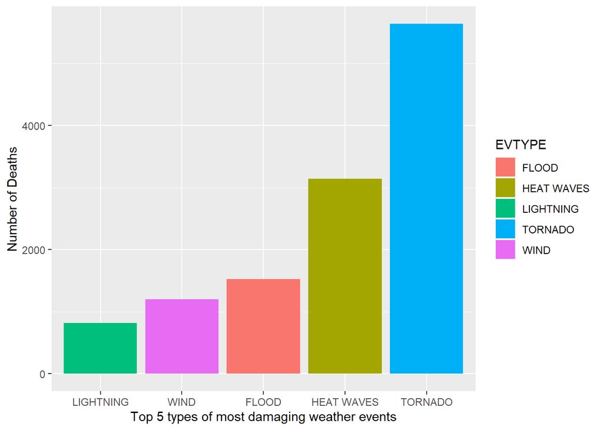

```r
library(ggplot2)

unifiedData %>%
      select(FATALITIES, EVTYPE) %>%
      group_by(EVTYPE) %>%
      summarise(sumF = sum(FATALITIES)) %>%
      top_n( n = 5, wt = sumF) %>%
      ggplot(aes(y = sumF, x = reorder(x = EVTYPE, X = sumF), fill = EVTYPE)) +
      geom_bar(stat = "identity") +
      xlab(label = "Top 5 types of most damaging weather events") +
      ylab(label = "Number of Deaths")
```

##### And here we can see the response related to Injuries

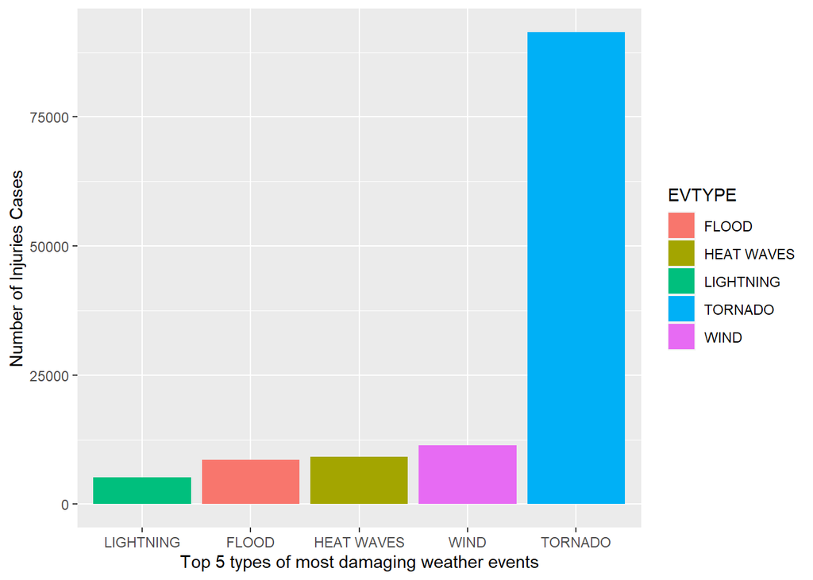

```r
unifiedData %>%
      select(INJURIES, EVTYPE) %>%
      group_by(EVTYPE) %>%
      summarise(SumI = sum(INJURIES)) %>%
      top_n(n = 5, wt = SumI) %>%
      ggplot(aes(y = SumI, x = reorder(x = EVTYPE, X = SumI), fill = EVTYPE))+
      geom_bar(stat = "identity") +
      xlab(label = "Top 5 types of most damaging weather events") +
      ylab(label = "Number of Injuries Cases")
```

### Question 2:

#### Across the United States, what types of weather events have the greatest economic consequences?

##### In the following plot we can see which climatic events had the most impact on the United States economy in the period studied:

[figure not shown]

```r
unifiedData %>%
      select(VALUE, EVTYPE) %>%
      group_by(EVTYPE) %>%
      summarise(SumV = sum(VALUE)/1000000) %>%
      top_n(n = 5, wt = SumV) %>%
      ggplot(aes(y = SumV, x = reorder(x = EVTYPE, X = SumV), fill = EVTYPE)) +
      scale_color_discrete(name="Weather Events") +
      geom_bar(stat = "identity") +
      xlab(label = "Top 5 types of most expensive weather events") +
      ylab(label = "Millons of Dollars")
```